# Customer Analysis of Cyclistic:

A Bike-Sharing Company

### PROJECT OVERVIEW

This is the analysis performed on Cyclistic’s bike sharing data. The purpose of this analysis is for Cyclistic to provide casual and annual members with the best cost saving solution. Cyclistic believe that some casual members can benefit from becoming annual members.

### OBJECTIVES:

- Encourage casual riders to become annual members
- Increase the number of new annual members

### DELIVERABLES:

1. Description of Data Source used
2. Documentation of all cleaning or manipulation of data
3. A summary of analysis
4. Supporting visualization and key findings
5. Top three (3) recommendations based on findings

### METHOD

Utilizing the data processing method of ask, prepare, process, analyze, share, and act to complete the objective and provide a solution for the client.

#### ASK

For the first step in the data analysis process, we have to start by asking the right questions.

- How do the annual members and casual riders use Cyclistic differently?
  - How often do casual members use the service versus annual members
  - What data do we need to consider and what are extra
  - What is the average time used for each user type
  - What is the max time used for each user and bike type
  - What is the standard deviation of the time used for each user and bike type

#### PREPARE

For this process, the data will need to be downloaded and review on what information is given. From here, we can determine what processing steps to take based on the data provided.

- What information can be used?
- Are there any inconsistencies or missing values?
- What information need to be extrapolated?
- Install and load the correct packages

```r
suppressPackageStartupMessages({
pacman::p_load(ggplot2, tidyr, dplyr, tidyverse, lessR, janitor, here, dslabs)
})
```

#### PROCESS

The process of cleaning and organizing the data will be detailed in this notebook. The codes and results will be shown as each point is addressed.

#### ANALYZE

The analyze will be detailed in this notebook. As the questions in the ask section, the detailed analysis will answer each and will reach a conclusion. At the end of the analysis, the data will reveal what differentiate annual members from the casual riders.

#### SHARE

In conculusion, visualation will be presented to the stakeholders in this notebook. A minimum of three (3) solutions wil be provided to the stakeholders to select and act

### PROCESS AND ANALYZE

#### Loading the dataset

R Studio will be used and we will call this dataset “cyclistic”. After loading the dataset we want to view the data and explore the structure.

```r
library(readr)
cyclistic <- read_csv("Desktop/Case Study 1/202303-cyclistic.csv")
```

```r
# This will show the structure of the dataset
str(cyclistic)
```

```
spc_tbl_ [258,678 × 13] (S3: spec_tbl_df/tbl_df/tbl/data.frame)
 $ ride_id           : chr [1:258678] "6842AA605EE9FBB3" "F984267A75B99A8C" "FF7CF57CFE026D02" "6B61B916032CB6D6" ...
 $ rideable_type     : chr [1:258678] "electric_bike" "electric_bike" "classic_bike" "classic_bike" ...
 $ started_at        : POSIXct[1:258678], format: "2023-03-16 08:20:34" ...
 $ ended_at          : POSIXct[1:258678], format: "2023-03-16 08:22:52" ...
 $ start_station_name: chr [1:258678] "Clark St & Armitage Ave" "Public Rack - Kedzie Ave & Argyle St" "Orleans St & Chestnut St (NEXT Apts)" "Desplaines St & Kinzie St" ...
 $ start_station_id  : chr [1:258678] "13146" "491" "620" "TA1306000003" ...
 $ end_station_name  : chr [1:258678] "Larrabee St & Webster Ave" NA "Clark St & Randolph St" "Sheffield Ave & Kingsbury St" ...
 $ end_station_id    : chr [1:258678] "13193" NA "TA1305000030" "13154" ...
 $ start_lat         : num [1:258678] 41.9 42 41.9 41.9 41.9 ...
 $ start_lng         : num [1:258678] -87.6 -87.7 -87.6 -87.6 -87.7 ...
 $ end_lat           : num [1:258678] 41.9 42 41.9 41.9 41.9 ...
 $ end_lng           : num [1:258678] -87.6 -87.7 -87.6 -87.7 -87.7 ...
 $ member_casual     : chr [1:258678] "member" "member" "member" "member" ...
 - attr(*, "spec")=
  .. cols(
  ..   ride_id = col_character(),
  ..   rideable_type = col_character(),
  ..   started_at = col_datetime(format = ""),
  ..   ended_at = col_datetime(format = ""),
  ..   start_station_name = col_character(),
  ..   start_station_id = col_character(),
  ..   end_station_name = col_character(),
  ..   end_station_id = col_character(),
  ..   start_lat = col_double(),
  ..   start_lng = col_double(),
  ..   end_lat = col_double(),
  ..   end_lng = col_double(),
  ..   member_casual = col_character()
  .. )
 - attr(*, "problems")=<externalptr>
```

Noting the results from the dataset. There are 13 columns and 3 identifier columns. The identify columns are the ride_id, rideable_type, and member_casual.

- ride_id is the individual rental transaction.
  - Initially, there was a question of whether this is the individual bike ID or rider id. It was determined that this was the transaction ID since there are no distinct values (see “null check”).
- rideable_type is the type of bike it is
- member_casual is the whether or not the rider is a member or casual rider

#### Reviewing the data

From the dataset, we need to determine if there are any missing values, how many distinct values, and what they are. The code below will show a count of which columns have NULL values and how many.

```r
null_check <- c(1:ncol(cyclistic))
  for(i in 1:ncol(cyclistic)){
    null_check[i] <- sum(is.na(cyclistic[,i]))}
null_check <- data.frame(colnames(cyclistic), null_check)
```

```r
# Execute to display the number NULL values for each attribute
null_check
```

| colnames.cyclistic. | null_check |
| --- | --- |
| ride_id | 0 |
| rideable_type | 0 |
| started_at | 0 |
| ended_at | 0 |
| start_station_name | 35910 |
| start_station_id | 35910 |
| end_station_name | 38438 |
| end_station_id | 38438 |
| start_lat | 0 |
| start_lng | 0 |

[output cut: 3 more lines]

Next, the code below will determine what the distinct values are and how many of each.

```r
num_distinct <- c(1:ncol(cyclistic))
  for(i in 1:ncol(cyclistic) ){
    num_distinct[i] <- as.integer(count(distinct(cyclistic[i])))}
num_distinct <- data.frame(colnames(cyclistic), num_distinct)
```

```r
# Run this to display the number of distinct values for each attribute
num_distinct
```

| colnames.cyclistic. | num_distinct |
| --- | --- |
| ride_id | 258678 |
| rideable_type | 3 |
| started_at | 238046 |
| ended_at | 238406 |
| start_station_name | 989 |
| start_station_id | 970 |
| end_station_name | 1003 |
| end_station_id | 980 |
| start_lat | 97749 |
| start_lng | 97276 |

[output cut: 3 more lines]

#### Organize the dataset

After the initial review of the dataset, the primary focus was determined to be ride_id, rideable_type, started_at, ended_at, and member_casual. Additional information was need and will utilize the existing attributes to extrapolate the time rented by each rider type and bike type.

To extrapolate the time rented, we need to take the date and time difference from ended_at and started_at.

```r
cyclistic <- cyclistic %>% mutate(time_used=as.numeric(difftime(cyclistic$ended_at, cyclistic$started_at, units = "secs")))

# Set aside a value for total number of rider
total_rider <- sum(cyclistic$member_casual=="member")+sum(cyclistic$member_casual=="casual")
total_casual <- sum(cyclistic$member_casual=="casual")
total_member <- sum(cyclistic$member_casual=="member")
```

Let’s take a look at some of the values. The first anbalysis will be to calculate the average and longest time a casual rider rented a bike. Afterward, we can use the same code and change the filter to analyze the same value but for annual members.

```r
# For better visual and ablity to display values in inline code, we created a table for the summarized data

# Casual riders who use electric bikes
cyclistic %>% filter(rideable_type == "electric_bike" & member_casual == "casual") %>%
                                                    summarize(casual_mean_time_min = (mean(time_used)/60),
                                                              casual_max_time_min = (max(time_used)/60),
                                                              casual_max_time_hr = (max(time_used)/3600))
```

| casual_mean_time_min | casual_max_time_min | casual_max_time_hr |
| --- | --- | --- |
| 10.72597 | 479.8667 | 7.997778 |

```r
# Casual riders who use classic bikes
cyclistic %>% filter(rideable_type == "classic_bike" & member_casual == "casual") %>%
                                                    summarize(casual_mean_time_min = (mean(time_used)/60),
                                                              casual_max_time_min = (max(time_used)/60),
                                                              casual_max_time_hr = (max(time_used)/3600))
```

| casual_mean_time_min | casual_max_time_min | casual_max_time_hr |
| --- | --- | --- |
| 26.00726 | 1559.933 | 25.99889 |

```r
# Casual riders who use docked bikes
cyclistic %>% filter(rideable_type == "docked_bike" & member_casual == "casual") %>%
                                                    summarize(casual_mean_time_min = (mean(time_used)/60),
                                                              casual_max_time_min = (max(time_used)/60),
                                                              casual_max_time_hr = (max(time_used)/3600))
```

| casual_mean_time_min | casual_max_time_min | casual_max_time_hr |
| --- | --- | --- |
| 132.377 | 16808.07 | 280.1344 |

```r
NA
```

Below are the results for the casual riders:

- Electric Bike (**39725** rentals):
  - Longest Rental Time:
    - **479** minutes or **8** hours
  - Average Rental Time:
    - **10** minutes or **0** hours
- Classic Bike (**19456** rentals):
  - Longest Rental Time:
    - **1559** minutes or **26** hours
  - Average Rental Time:
    - **26** minutes or **0** hours
- Docked Bike (**3020** rentals):
  - Longest Rental Time:
    - **16808** minutes or **280** hours
  - Average Rental Time:
    - **132** minutes or **2** hours

```r
# Annual members who use electric bikes
cyclistic %>% filter(rideable_type == "electric_bike" & member_casual == "member") %>%
                                                    summarize(mean_time_min = (mean(time_used)/60),
                                                              max_time_min = (max(time_used)/60),
                                                              max_time_hr = (max(time_used)/3600))
```

| mean_time_min | max_time_min | max_time_hr |
| --- | --- | --- |
| 9.428248 | 480.45 | 8.0075 |

```r
# Annual members who use classic bikes
cyclistic %>% filter(rideable_type == "classic_bike" & member_casual == "member") %>%
                                                    summarize(mean_time_min = (mean(time_used)/60),
                                                              max_time_min = (max(time_used)/60),
                                                              max_time_hr = (max(time_used)/3600))
```

| mean_time_min | max_time_min | max_time_hr |
| --- | --- | --- |
| 11.70178 | 1559.667 | 25.99444 |

After the first iteration analysis, the code below was used to find mean and max time for docked bikes. However, the results show that there are no docked bike used by annual members and the code produces NA and errors. The below is the code use to confirm there are no members who use docked bikes. To prevent the code from running, it was made into a comment

```r
# Annual members who use docked bikes

# cyclistic %>% filter(rideable_type == "docked_bike" & member_casual == "member") %>%
#                                                    summarize(casual_mean_time_min = (mean(time_used)/60),
#                                                              casual_max_time_min = (max(time_used)/60),
#                                                              casual_max_time_hr = (max(time_used)/3600))
```

Below are the results for an annual member:

- Electric Bike (**108850** rentals):
  - Longest Rental Time:
    - **480** minutes or **8** hours
  - Average Rental Time:
    - **9** minutes or **0** hours
- Classic Bike (**87627** rentals):
  - Longest Rental Time:
    - **1559** minutes or **26** hours
  - Average Rental Time:
    - **11** minutes or **0** hours
- Docked Bike:
  - NOT USED BY ANNUAL MEMBERS

#### Results and Analysis

Let’s evaluate the difference in uses between casual riders and members

```r
casual_longest_time <- as.integer(max(cyclistic$time_used[cyclistic$member_casual == "casual"])/3600)
member_longest_time <- as.integer(max(cyclistic$time_used[cyclistic$member_casual == "member"])/3600)

casual_avg_time <- as.integer(mean(cyclistic$time_used[cyclistic$member_casual == "casual"])/60)
member_avg_time <- as.integer(mean(cyclistic$time_used[cyclistic$member_casual == "member"])/60)

casual_over_cavg <- cyclistic %>% filter(member_casual=="casual" & time_used >= (casual_avg_time*60)) %>% count(member_casual)
casual_over_mavg <- cyclistic %>% filter(member_casual=="member" & time_used >= (casual_avg_time*60)) %>% count(member_casual)
```

Looking at the longest rental time, a casual biker was shown to have used the service **11.2** times longer than an annual member. The average casual rider use the bikes **2.1** times more than members.

## Visuals

### Casual Riders

As a presentation to stakeholder, we will present a donut chart of which bikes are used by casuals and members.

[output not shown]

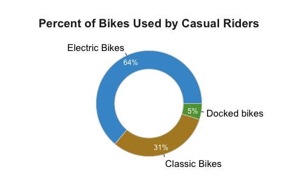

```r
casual_ebike <- round(sum(cyclistic$rideable_type == "electric_bike" & cyclistic$member_casual == "casual")/total_casual*100, digits = 2)
casual_cbike <- round(sum(cyclistic$rideable_type == "classic_bike" & cyclistic$member_casual == "casual")/total_casual*100, digits = 2)
casual_dbike <- round(sum(cyclistic$rideable_type == "docked_bike" & cyclistic$member_casual == "casual")/total_casual*100, digits = 2)

# Donut Chart
slices <- c(casual_ebike, casual_cbike, casual_dbike)
lbls <- c("Electric Bikes","Classic Bikes", "Docked bikes")
slice_df <- data.frame(lbls, slices)
PieChart(lbls,slices, main = "Percent of Bikes Used by Casual Riders")
```